# Naive Bayes

```r
library(mlbench)
data(HouseVotes84)
```

barplots for specific issue

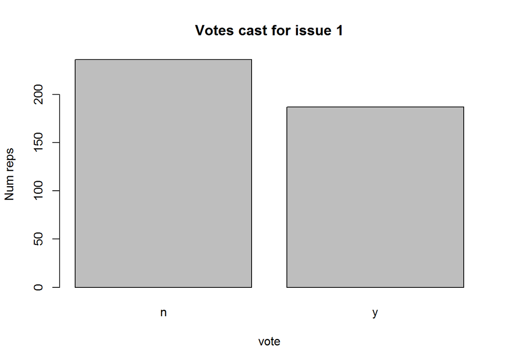

```r
plot(as.factor(HouseVotes84[,2]))
title(main='Votes cast for issue 1', xlab="vote", ylab= "Num reps" )
```

By party

```r
Repub <-  HouseVotes84$Class=="republican"
Democrat <- HouseVotes84$Class=="democrat"
```

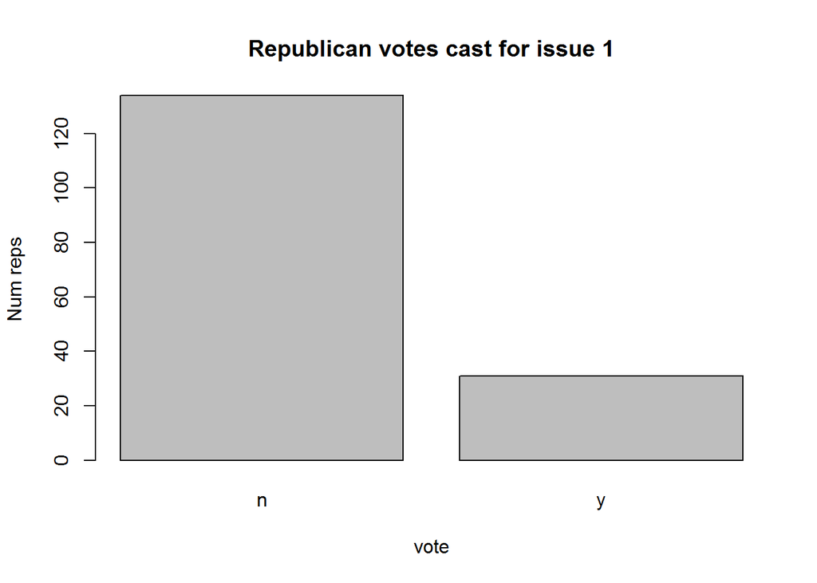

```r
plot(as.factor(HouseVotes84[Repub,2]))
title(main="Republican votes cast for issue 1", xlab="vote", ylab="Num reps")
```

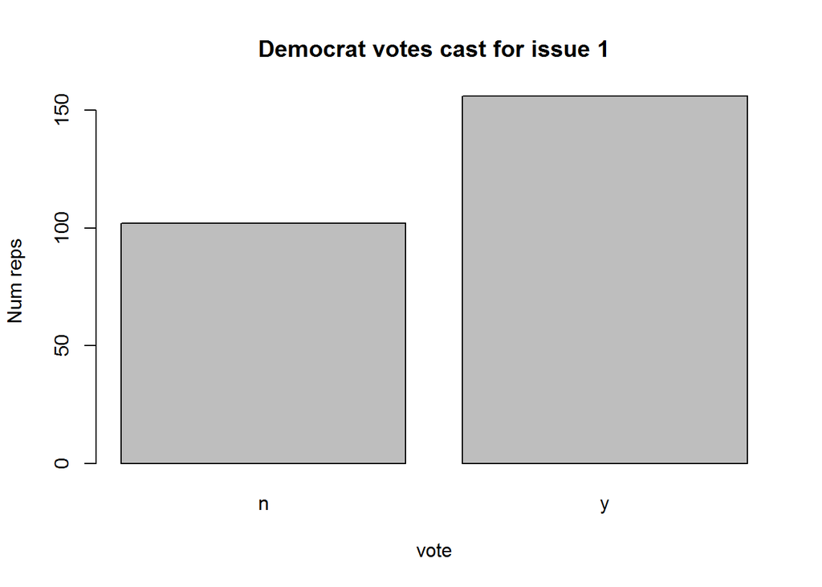

```r
plot(as.factor(HouseVotes84[Democrat,2]))
title(main="Democrat votes cast for issue 1", xlab="vote", ylab="Num reps")
```

We have a lot of NA. We are going to impute the values

Functions needed for imputation

function to return number of NAs by vote and class (democrat or republican)

```r
na_by_col_class <- function (col,cls){return(sum(is.na(HouseVotes84[,col]) & HouseVotes84$Class==cls))}
```

function to compute the conditional probability that a member of a party will cast a “yes” vote for a particular issue. The probability is based on all members of the party who actually cast a vote on the issue (ignores NAs).

```r
p_y_col_class <- function(col,cls){
  sum_y<-sum(HouseVotes84[,col]=="y" & HouseVotes84$Class==cls,na.rm = TRUE)
  sum_n<-sum(HouseVotes84[,col]=="n" & HouseVotes84$Class==cls,na.rm = TRUE)
  return(sum_y/(sum_y+sum_n))
}
```

```r
p_y_col_class(5,"democrat")
```

```
## [1] 0.05405405
```

impute missing values. If the republican congresman didn’t vote, then we are allocating ‘y’ or ‘n’ based on if their party voted ‘y’ or ‘n’

```r
for (i in 2:ncol(HouseVotes84)) {
  if(sum(is.na(HouseVotes84[,i])>0)) {
    c1 <- which(is.na(HouseVotes84[,i])& HouseVotes84$Class=="democrat",arr.ind = TRUE)
    c2 <- which(is.na(HouseVotes84[,i])& HouseVotes84$Class=="republican",arr.ind = TRUE)
    HouseVotes84[c1,i] <-
      ifelse(runif(na_by_col_class(i,"democrat"))<p_y_col_class(i,"democrat"),"y","n")
    HouseVotes84[c2,i] <-
      ifelse(runif(na_by_col_class(i,"republican"))<p_y_col_class(i,"republican"),"y","n")}
}
```

divide into test and training sets create new col “train” and assign 1 or 0 in 80/20 proportion via random uniform dist

```r
HouseVotes84[,"train"] <- ifelse(runif(nrow(HouseVotes84))<0.80,1,0)
```

get col number of train / test indicator column (needed later)

```r
trainColNum <- grep("train",names(HouseVotes84))
```

separate training and test sets and remove training column before modeling

```r
trainHouseVotes84 <- HouseVotes84[HouseVotes84$train==1,-trainColNum]
testHouseVotes84 <- HouseVotes84[HouseVotes84$train==0,-trainColNum]
```

load e1071 library and invoke naiveBayes method

```r
library(e1071)
nb_model <- naiveBayes(Class~.,data = trainHouseVotes84)

nb_model
```

```
##
## Naive Bayes Classifier for Discrete Predictors
##
## Call:
## naiveBayes.default(x = X, y = Y, laplace = laplace)
##
## A-priori probabilities:
## Y
##   democrat republican
##  0.5833333  0.4166667
##
## Conditional probabilities:
##             V1
## Y                    n         y
##   democrat   0.4238095 0.5761905
##   republican 0.8066667 0.1933333
##
##             V2
## Y                    n         y
##   democrat   0.4857143 0.5142857
##   republican 0.5133333 0.4866667
##
##             V3
## Y                    n         y
##   democrat   0.1095238 0.8904762
##   republican 0.8666667 0.1333333
##
##             V4
## Y                     n          y
##   democrat   0.94285714 0.05714286
##   republican 0.01333333 0.98666667
##
##             V5
## Y                     n          y
##   democrat   0.75714286 0.24285714
##   republican 0.04666667 0.95333333
##
##             V6
## Y                    n         y
##   democrat   0.5047619 0.4952381
```

[output cut: 36 more lines]

```
##
##             V14
## Y                    n         y
##   democrat   0.6714286 0.3285714
##   republican 0.0200000 0.9800000
##
##             V15
## Y                     n          y
##   democrat   0.38095238 0.61904762
##   republican 0.91333333 0.08666667
##
##             V16
## Y                     n          y
##   democrat   0.05714286 0.94285714
##   republican 0.34666667 0.65333333
```

Lets test the model

```r
nb_test_predict <- predict(nb_model,testHouseVotes84[,-1])
```

fraction of correct predictions

```r
mean(nb_test_predict==testHouseVotes84$Class)
```

```
## [1] 0.92
```

```r
#confusion matrix
table(pred=nb_test_predict,true=testHouseVotes84$Class)
```

```
##             true
## pred         democrat republican
##   democrat         52          1
##   republican        5         17
```